# Seven questions × everything we have

Results synthesis for manuscripts, the iGEM presentation and the wiki — status as of 2026-07-29

Published

July 29, 2026

**NoteWhat this document is**

Prof. Espinoza’s email of 2026-07-27 opened seven items, one of them marked immediate. This document connects those seven to everything we currently have:

- **§1** the seven items unpacked — what was asked, what it actually requires, where each stands.
- **§2** what our material actually is — five isolates are three strains, and there is only one phage. Every number later rests on this.
- **§3** a complete results table — every result in the repository, with an evidence grade and where it can be used.
- **§4** the full answer to item 7 — the O-antigen locus comparison.
- **§5** next steps, and three things we need from the PI.
- **Appendix** figures, how each was made, and a source map.

§1–§3 and §5 are an index and a status report; §4 is a complete analysis. This is the English counterpart of `2026-07-28_results_synthesis.qmd`; the two are kept in sync.

**TipBottom line — the seven questions, answered (terse)**

Answers up front; detail in §1 and the appendix.

1. **Synthesize results** → this document. **Done.**
2. **Graphical abstract** → **not started.** Only this and #5 remain open.
3. **Bacterial genome diagram** → **done.** App A5 — three closed genomes, O-antigen cassette ringed.
4. **Phage genome map, tail spike highlighted** → **done.** App B1/B2 — CDS_0011 outlined.
5. **Tail spike 3D + metagenomic variable regions** → 3D **done** (App B3). Variable-region half **blocked**: MGnify contigs carry no host labels, so specificity-determining positions can’t be found (variable ≠ specificity). Salvageable = a per-residue *conservation* profile from the PI’s 15,775-seq MSA — never “what determines binding”.
6. **3D of enzymatic domains** → **done.** App B3. The confirmed GH5 is CDS_0012, a **separate protein**, not a domain of the tail spike.
7. **O-PS typing + compare 3 isolates** → **done** (§4). Three strains carry **three non-homologous O-antigen cassettes in one ihfB-flanked slot** → predicts Φ8 won’t plaque Strain 1/3 (the PI’s 2026-07-04 host-range assay covering these strains was run; the readout is pending his notebook). And **no serotyping tool applies** to this taxon (PAst is *P. aeruginosa*-only; Kaptive has no Pseudomonas DB) — a publishable negative.

**2026-07-29 conversation (C1–C6):** CDS_0010 is now *unknown protein* (glycosidase withdrawn, C1); constructs are all N-terminal, no C-tag (C2); **9-2-1 Φ8 is a novel ~62 kb, likely-temperate podovirus** — podovirus virion synteny confirms the structural module (C4, App B7), but it shares ~0 orthologs with cultured T7-likes, so “T7-like” is organizational only; the tail is **group-D-*like*** but lacks the T4gp10 anchor (App B8; C11–C13). C6 (host-range table) is pending the PI.

# 1 The seven questions

## 1.1 What was asked, and what it requires

| # | The PI’s words | What is actually being asked for | What we are really looking at | Status |
| --- | --- | --- | --- | --- |
| **1** | *Let’s start synthesizing our results so we can begin preparing figures for your presentation(s) and manuscript(s).* | Pull scattered results into usable figures and tables | Two audiences: **manuscripts** (the MRA, and a later phage paper) and the **iGEM presentation / wiki** | 🟢 **this document** |
| **2** | *I suggest creating a graphical abstract that summarizes the overall project.* | One figure for the whole project | Needs §3 to settle first, and the central claim still lacks wet-lab support | 🔴 not started |
| **3** | *Prepare a diagram of the bacterial genomes we sequenced.* | A visual of the bacterial genomes | Five isolates → three strains, one circular map each | 🟢 **done → Appendix A5** |
| **4** | *Create a genome map of our phage highlighting the structural proteins, particularly the tail spike protein.* | Phage genome map with structural proteins marked | 80 CDS, redrawn on the canonical coordinates | 🟢 **done → Appendix B1, B2** |
| **5** | *Generate a 3D model of the tail spike protein, highlighting the variable regions identified from the metagenomic analysis.* | Tail spike 3D + variable regions | **The model exists, but the “metagenomic variable-region analysis” does not** — and the original plan was rejected on methodological grounds by our own review | 🔴 blocked (§1.3) |
| **6** | *Generate 3D models of the enzymatic domains within the tail spike protein.* | 3D of the enzymatic domains | AF3 folds and the domain map were already complete | 🟢 **done → Appendix B3** |
| **7** | *(immediate)* *identify bioinformatics tools capable of predicting the O-PS type from bacterial genome sequences, and compare across our three isolates* | O-antigen typing + a three-way comparison | **No tool applies**; we compared the loci directly instead | 🟢 **done → §4** |

## 1.2 These seven are really two threads

**The first is deliverables** (1, 2, 3, 4, 6). The underlying data was already on disk; what was missing was the drawing. These were not hard — the hard part was *not drawing them wrong*: the existing phage figure was mirrored, two CDS numbering schemes coexist, and one of the “enzymatic domains” is unsupported.

**The second is a real scientific question** (7, and the blocked 5). Item 7 turns out to be where the whole storyline closes:

```
we have phage 9-2-1 Φ8 + three host strains
        ↓
the tail spike is a β-helix depolymerase (a sugar-degrading enzyme)
        ↓
therefore the receptor is the host-surface O-antigen SUGAR, not a protein
        ↓  ← which is why protein–protein docking was falsified and retired (§3, group F)
therefore what should be compared is the strains' O-antigen loci      ← item 7
        ↓
and the three strains do carry three non-homologous cassettes         ← §4
        ↓
→ yielding a falsifiable prediction: Φ8 should not plaque on the other two
```

## 1.3 Why item 5 is blocked

The “metagenomic variable-region” analysis the PI refers to **has never been done**, and `2026-07-12_rbp_variable_region_plan_review.md` already stress-tested the original plan and concluded it cannot be run as designed:

- **A central methodological error** — *a variable region is not a specificity-determining position*. What matters is SDPs (positions conserved *within* a functional subgroup and different *between* subgroups), not raw high-entropy columns, most of which are neutral drift.
- **A fatal data gap** — MGnify / metagenome sequences carry **no host or receptor labels**, so there is no way to get from sequence to “what does this RBP bind”.

That review ends on three questions awaiting a decision, and states explicitly that no code should be written until the label source is settled.

**Half of it can still be salvaged.** The PI’s own AF3 job folders contain an alignment of **15,775 sequences** for CDS_0011 — deep enough to compute a per-residue conservation profile and paint it onto the structure. That is an honest figure (conserved core vs variable surface). The caption must say it shows **conservation**, which is not the same as “the positions that determine binding”.

# 2 What our material actually is

Everything downstream rests on this section.

## 2.1 Five isolates, three strains

`data/bacteria_genome/` holds **five** isolates. Per `code/0627_unique_strain_table.ipynb` they collapse into **three ANI-distinct strains**:

| Strain | Isolates | Species (GTDB) | Genome | Note |
| --- | --- | --- | --- | --- |
| **Strain 1** | 8-5-2, 10-10-2 | *Pseudomonas_E* sp013179515 | ~5.93 Mb | 99.997% ANI to each other |
| **Strain 2** | 9-2-1, 9-6-2 | *Pseudomonas_E* sp013179515 | ~6.18 Mb | **100.000%** ANI to each other; **the phage host** |
| **Strain 3** | 8-10-2 | *P. capeferrum* | ~5.70 Mb | 87.4–87.7% ANI to the others — a different species |

Strain 1 and Strain 2 sit at 99.38–99.42% ANI: same species, different strains, but ~250 kb apart in genome size.

**CautionTwo things to be careful about**

1. **We have not confirmed which three the PI meant by “our three isolates”.** We assume the three strain representatives. This needs one line from him (§5).
2. The MRA draft (`2026-06-27_MRA_Pseudomonas.docx`) covers only the four *sp013179515* isolates and **excludes 8-10-2**, so the MRA says “two strains” while this document says three. That is a **difference in scope, not a contradiction**.

## 2.2 There is only one phage

**9-2-1 Φ8** is the only phage sequenced so far: a single contig of **62,338 bp** (**62,416 bp** in the PI’s assembly), linear, with a **77 bp direct terminal repeat** at both ends, and 80 CDS. It was isolated on site 9-2-1; its host is **Strain 2**.

**9-6-2 Φ8 has not been sequenced** (same 06/05 plaque batch).

**WarningTwo CDS numbering schemes coexist**

The same phage was annotated twice, on **opposite assembly orientations**, so the CDS numbers run in opposite directions (77 of 80 are the same protein, simply renumbered).

**The PI’s `UUAIURNK_` numbering has been canonical since 2026-07-16**; our older `FHABPWTM_` numbers are deprecated. Convert via `code/0713_espinoza_structural_mapping/cds_lookup.tsv`. Anything written before 2026-07-16 may still use the old numbers.

The easiest trap: the PI’s **CDS_0011 (tail spike, 941 aa)** corresponds to **CDS_0015 + CDS_0016 merged** in our old annotation — draw from the old GFF and the tail spike splits into two ORFs.

# 3 Complete results table

**TipHow to read the evidence grades**

| Mark | Meaning |
| --- | --- |
| ✅ | **Confirmed** — data plus controls or agreement between independent methods |
| 🟡 | **Provisional** — computational inference, single method, no experimental test |
| 🔴 | **Incomplete, or explicitly a prediction** — must not be cited as a result |
| ⛔ | **Negative result** — attempted, failed, retired. **Valuable, and publishable** |

## 3.1 A. Bacterial hosts

| # | Result | Evidence | Source | Use |
| --- | --- | --- | --- | --- |
| A1 | **Complete closed genomes for all five isolates**: single circular contig each, ONT + Autocycler; CheckM completeness 99.74–100.00% | ✅ | `data/bacteria_genome/` | paper·talk·wiki |
| A2 | Genome sizes 5.70–6.18 Mb; GC 62.4–62.6%; sequencing depth 67–96× | ✅ | `code/output/0626_genome_comparison/table1_genome_summary.csv` | paper |
| A3 | **Five isolates collapse to three ANI-distinct strains** (§2.1) | ✅ | `code/0627_unique_strain_table.ipynb` | paper·talk·wiki |
| A4 | Taxonomy: four isolates are *Pseudomonas_E* sp013179515; 8-10-2 is *P. capeferrum* | ✅ | sourmash / GTDB | paper |
| A5 | Closest public relative is *Pseudomonas* sp. **CM27** at ~99.2% ANI; **not** *P. aeruginosa* (80.4%) and not *P. putida* (89.4%) | ✅ | `code/0623_metagenome_rbp/out_finding_rbps/ani/` | paper·wiki |
| A6 | Bakta annotation complete: 5,055–5,449 CDS per isolate, coding density ~89.6% | ✅ | `data/bacteria_genome/*/annotation/` | paper |
| A7 | **Surface-receptor mining: 441 candidate receptors → 178 clusters**; 86–91 per isolate; **12 shared by all five**; 79 unique to 8-10-2 | ✅ | `code/0626_genome_comparison.ipynb` | paper·talk |
| A8 | Receptor classification against 13 *E. coli* OMP references: of 237, **156 unclassified**, fhuA 41, btuB 12, ompA 12, yncD 7, tolC 6, tsx 3 | 🟡 | `code/output/0620_receptor_classification/class_summary.tsv` | paper |
| A9 | **The three strains carry three non-homologous O-antigen cassettes** in the same `ihfB`-flanked slot; only **4 of 45** ortholog clusters are shared by all three | ✅ | **§4** | **paper·talk·wiki** |
| A10 | Both clone pairs have **100.0% identical** O-antigen cassettes (internal control passed) | ✅ | **§4.4** | paper |
| A11 | All five carry a complete 12-gene **alginate operon** (`algD–algA`); **no psl locus** | 🟡 | Bakta annotation | paper |
| A12 | The dTDP-rhamnose pathway is complete in all three strains but differently arranged (Strain 3 keeps the whole operon outside the cassette) | ✅ | **§4.3** | paper |

## 3.2 B. Phage genome

| # | Result | Evidence | Source | Use |
| --- | --- | --- | --- | --- |
| B1 | **Complete 9-2-1 Φ8 genome**: single contig **62,338 bp** (PI’s assembly 62,416 bp), GC 62%, ~1014× coverage | ✅ | `data/phage_genome/9-2-1/assembly/` | paper·talk·wiki |
| B2 | **Topology resolved: linear with a 77 bp direct terminal repeat** (not circular) | ✅ | `.../assembly/NOTES.md` | paper |
| B3 | Pharokka annotation: **80 CDS**, coding density 96.3%, 2 tRNA, 0 CRISPR | ✅ | `code/0713_espinoza_structural_mapping/pharokka_espinoza/` | paper |
| B4 | **Structural module mapped**: 11 head & packaging, 3 tail (CDS_0009/0010/0011), major head CDS_0017, portal CDS_0020, internal virion protein CDS_0008 | ✅ | as above | paper·talk·wiki |
| B5 | **Safety: zero VFDB virulence factors, zero CARD resistance genes** | ✅ | `.../top_hits_{vfdb,card}.tsv` | **safety forms·wiki** |
| B6 | No mash hit against INPHARED → a novel phage | 🟡 | `pharokka_top_hits_mash_inphared.tsv` | paper·wiki |
| B7 | Two integration & excision genes annotated → **possibly temperate** | 🟡 | Pharokka categories | paper (safety) |
| B8 | The PI’s structural annotation: AlphaFold + foldseek matched the virion to *Ralstonia* phage **GP4** (a podovirus) | 🟡 | `code/0713_espinoza_structural_mapping/` | talk |
| B9 | **CDS numbering crosswalk** (PI’s `UUAIURNK_` ↔︎ our `FHABPWTM_`; 80 rows, sequence-verified, 77/80 identical) | ✅ | `.../cds_lookup.tsv` | internal, essential |
| B10 | **The large terminase subunit is not annotated** (only the small subunit, CDS_0027) → formal taxonomy (terL tree / VIRIDIC) **cannot be run** | 🔴 | `terL.faa` is 0 bytes | blocks the formal claim in B6 |
| B11 | 9-6-2 Φ8 **not yet sequenced** | 🔴 | `NOTES.md` UNDONE | — |

## 3.3 C. Tail spike and enzymatic domains

[output not shown]

## 3.4 D. RBP databases and metagenomes

| # | Result | Evidence | Source | Use |
| --- | --- | --- | --- | --- |
| D1 | **Literature RBP database: 1,673 unique sequences** (3 papers, 2,447 source records), of which **115 are Pseudomonas** | ✅ | `code/0619_literature_rbp_database/` | paper·wiki |
| D2 | RBP-by-receptor table, 1,215 rows; **173** high-confidence (experimentally or AF3 validated); 362 in the *E. coli* OMP class | ✅ | `rbp_by_receptor_class.tsv` | paper |
| D3 | **De novo RBP detection in the metagenomes** (PhageRBPdetect v4 / ESM-2): MG08 **632**, MG09 **661** | ✅ | `code/0701_phagerbp_metagenome/` | paper |
| D4 | **Surrogate-host analysis**: *P. putida* shares the most receptors with us (68 at ≥90% identity, max 99.4%); KT2440 has 71 phage records in PharBP | 🟡 | `code/output/0703_phage_host_matrix/host_overlap_summary.md` | paper·talk |
| D5 | **Methodological finding: PharBP is an RBP database, not a receptor database** — it has no bacterial-receptor field, so our receptor sequences cannot be looked up there | ✅ | `code/0701_pharbp_query/` | internal·paper (methods) |
| D6 | The metagenome RBPs have **never been aligned to CDS_0011** — the input item 5 presumes does not exist | 🔴 | — | blocks item 5 |

## 3.5 E. Wet lab

[output not shown]

## 3.6 F. Negative results (publishable, and worth publishing)

[output not shown]

## 3.7 G. Manuscripts and deliverables

| # | Result | Evidence | Source | Use |
| --- | --- | --- | --- | --- |
| G1 | **The MRA draft is written** (Chen, Wang, Yan, Escobar, Ignacio-Espinoza): four isolates, two strains, full methods section and Table 1 | 🟡 | `2026-06-27_MRA_Pseudomonas.docx` | paper |
| G2 | ⚠️ **Every GenBank / SRA accession is still `pending`** and data availability is still `XXX` → **submission is blocked on deposition, not on analysis** | 🔴 | as above | blocks G1 |
| G3 | The MRA excludes 8-10-2, which is why it says “two strains” where this document says three — scope, not contradiction | ✅ | §2.1 | internal consistency |

# 4 Item 7 in full: the O-antigen locus comparison

**Important**

**No tool applies.** Every in-silico O-PS serotyper is species-bound and ours is none of the supported species; this taxon has no reference serotype scheme, so **no O-type name can be assigned to any of our strains**.

Comparing the loci directly instead: **the three strains each carry a non-homologous O-antigen cassette in the same genomic slot.** Of 45 ortholog clusters, only **4** are shared by all three, and all four are generic sugar chemistry — **none of the assembly machinery is shared**.

Because our tail spike is a sugar-degrading enzyme whose receptor is that very O-antigen, this difference predicts directly that **Φ8 should not plaque on the other two strains**.

## 4.1 Why no existing tool applies

O-PS (O-polysaccharide, or O-antigen) is the outermost repeating sugar chain of the LPS in Gram-negative bacteria, and one of the most variable surface structures between strains. In-silico serotypers all work by matching a genome against a **species-specific reference database of serotypes** — so whether a tool is usable is entirely a question of species.

| Tool | Scope | Why it does not apply |
| --- | --- | --- |
| **PAst / PAst2.0** | *P. aeruginosa* OSA clusters O1–O20 | our isolates are ~**80% ANI** to PAO1 — a different species |
| **Kaptive** (all versions) | *Klebsiella*, *A. baumannii*, third-party *V. parahaemolyticus* | **no Pseudomonas database exists** |

**WarningPlease keep this distinction**

What we can deliver is that **the locus architecture differs**. We cannot deliver “Strain 1 is O-type X” — that does not exist for this taxon.

## 4.2 Method

### 4.2.1 Anchors rather than coordinates

An O-antigen locus is a variable cassette dropped into a conserved slot, so its position differs in every genome and the only stable landmark is its flanks. In all five genomes the upstream flank reads:

```
30S ribosomal protein S1
  → integration host factor subunit β (ihfB)
    → lipopolysaccharide assembly protein A
      → MBL fold metallo-hydrolase
        → [the variable O-antigen cassette starts here]
```

`ihfB` (also known as *himD*) is the canonical upstream flank of the *Pseudomonas* OSA cluster in the literature, so this anchor is principled rather than arbitrary.

### 4.2.2 Orthology decided by sequence, not by product name

Bakta will give two entirely unrelated glycosyltransferases the same product string, so calling genes shared or unique from labels would manufacture false overlap. Orthology here is decided by **MMseqs2 clustering** (≥30% identity, ≥50% coverage).

This paid off immediately: the chain-length regulators of Strain 1 and Strain 2 carry **two different Bakta labels** (`O-antigen chain length regulator` vs `Polysaccharide chain length determinant`) but the sequences show they are homologous — comparing by name would have missed it.

## 4.3 Results: three strains, three cassettes, one slot

| Strain | Locus tags | Genes | Span |
| --- | --- | --- | --- |
| **Strain 2** (9-2-1, 9-6-2) | `OHPLIO_01276–01298` / `PICBEH_01275–01297` | 23 | 26.5 kb |
| **Strain 1** (8-5-2, 10-10-2) | `PEMOGA_01378–01392` / `BPBBIK_01378–01392` | 15 | 17.0 kb |
| **Strain 3** (8-10-2) | `NEEDOG_01333–01357` | 25 | 38.2 kb |

**Distinctive content.** **Strain 2** carries a UDP-GlcNAc → 2,3-diacetamido-uronic acid route (`wbpA/wbpB/wbpD`-type), a DegT aminotransferase, `wzx`, a repeat-unit polymerase (`wzy`), `wbuB`, and an acetamidino modification module (amidotransferase + HisH + AglZ/HisF2). **Strain 1** carries `wbpL`, `epsG`, `capD` and four glycosyltransferases, with none of Strain 2’s amino-uronic route. **Strain 3** carries an O-antigen ligase, a separate polymerase, a D-glucuronyl C5-epimerase, a UDP-ManNAc dehydrogenase, and one 6.7 kb ORF (`NEEDOG_01355`).

**The dTDP-rhamnose pathway is complete in all three**, but differently arranged: Strains 1 and 2 place `rfbA/rfbB/rfbD` at the end of the cassette with `rmlC` elsewhere in the genome (`OHPLIO_00244`, `BPBBIK_00248`), while Strain 3 keeps the whole four-gene operon *outside* the cassette (`NEEDOG_00269–00272`, `rmlC` included) and retains only a lone `rfbD` inside it.

See **Appendix A3** for the main figure and **A4** for the cluster matrix.

## 4.4 The clone pairs are the control, and they pass

This step is not optional. The whole argument is that **ANI saturates while accessory loci diverge** — so we could not simply *assume* that 100%-ANI clones share this locus; it had to be measured.

- **9-2-1 vs 9-6-2** — all 23 genes hit at **100.0%** mean identity, on identical coordinates (1,409,400–1,435,896).
- **8-5-2 vs 10-10-2** — all 15 genes at **100.0%**.

**Across strain groups the cassettes barely correspond:**

| Comparison | Genes with a best hit | Mean identity | Median |
| --- | --- | --- | --- |
| Strain 2 ↔︎ Strain 1 | 9 of 23 | 71.9% | 67.4% |
| Strain 2 ↔︎ Strain 3 | 10 of 23 | 54.7% | 49.4% |
| Strain 1 ↔︎ Strain 3 | 6 of 15 | 63.5% | 61.7% |

**NoteWhy these counts deliberately do not reconcile with the cluster counts**

These are **best-hit-per-query in one direction, not reciprocal best hits**, and they use a looser cutoff (20% identity / 40% coverage) than the clustering below (30% / 50%). The two sets of numbers are **not meant to add up** — a gene can have a weak best hit without joining an ortholog cluster.

Of **45 ortholog clusters** (30% / 50%) across 101 cassette proteins, only **4** are shared by all three strains: a UDP-glucose 4-epimerase, a GT-family-4 transferase, a CapD-like protein and an SDR oxidoreductase. All generic sugar chemistry; **none of it assembly machinery** — no shared flippase, polymerase or chain-length regulator, i.e. none of the parts that determine what the O-antigen actually looks like. Strains 1 and 2 additionally share the dTDP-rhamnose trio and the chain-length regulator.

## 4.5 What this predicts — and what it does not

Two facts combine: **(1)** the tail spike is a β-helix depolymerase, so the receptor is the O-antigen sugar (C1, C2); **(2)** the three strains’ O-antigen cassettes are non-homologous (A9).

If this phage’s depolymerase reads Strain 2’s sugar, it should **not** infect the other two. Current evidence is shown in **Appendix C1**.

**ImportantThe key readout — already assayed 2026-07-04, data pending**

The PI **already spot-assayed 9-2-1 Φ8 against 8-5-2, 10-10-2 and 8-10-2** on 2026-07-04; we are waiting on his notebook to read out the result. What each outcome will mean:

- **No plaques** → the O-antigen mechanism of host range is confirmed and the storyline closes.
- **Plaques** → more interesting still: the second depolymerase (`CDS_0024`, C5) is acting, and the phage has two sugar specificities.

**Either outcome is publishable**, and it is the highest-value readout we are waiting on. Until the notebook arrives, E5 stays a prediction.

## 4.6 Limits — what cannot be said yet

**Caution**

1. **Do not say the O-antigen difference explains our observed host range.** The cross-strain assay was run on 2026-07-04, but the data is not yet in our hands — until we have it, this remains a **prediction**, not an explanation.
2. **No serotype can be named.** Every conclusion rests on Bakta product strings — gene annotation, not determined sugar structure — and this species has no reference serotype scheme.
3. **Strain 1 appears to lack a flippase and a polymerase; that is most likely an annotation artifact.** Its `Polysaccharide biosynthesis protein` and `EpsG family protein` are the usual labels for Wzx- and Wzy-family proteins, but Bakta assigns them no Pfam/InterPro domain here (UniRef50 only). They are left grey and unassigned in Appendix A3 rather than coloured on a guess. Confirming them needs InterProScan.
4. **The sugar structure itself has not been measured.** Gene content is not structure; that requires LPS extraction and mass spectrometry.

# 5 Next steps

| Priority | Item | Who | Why |
| --- | --- | --- | --- |
| 1 | Ask the PI whether the **CDS11 tagging is deliberate** (C9) | Alex | Twist has not confirmed processing yet — this is the window |
| 2 | **GenBank / SRA deposition** (G2) | Alex | blocks the MRA submission |
| 3 | **Retrieve the PI’s 2026-07-04 host-range notebook** (Φ8 × 8-5-2 / 10-10-2 / 8-10-2, E5) | Alex + PI | the assay is already run — this reads out E5, the highest-value result we are waiting on |
| 4 | Conservation profile painted on the structure (the salvageable half of item 5) | analysis | the 15,775-sequence MSA already exists |
| 5 | Graphical abstract (item 2) | TBD | only items 2 and 5 remain open, so this can start |
| 6 | Sequence 9-6-2 Φ8 (B11) | wet lab | the second phage |
| 7 | Confirm the Wzx/Wzy family assignments (§4.6, limit 3) | analysis | needs InterProScan, not available locally |
| 8 | Foldseek naming of the tail spike β-helix family (C10) | analysis | the fold call currently has geometric evidence only |

**Completed 2026-07-29**: items 3, 4 and 6 — see `code/0729_prof_figures/`.

**ImportantQuestions for the PI**

1. **Which three isolates did you mean?** We assumed the three strain representatives (8-5-2 / 9-2-1 / 8-10-2), but this has not been confirmed.
2. **What is the evidence that CDS_0010 is a glycosidase?** **RESOLVED (2026-07-29):** the PI withdrew the glycosidase call — CDS_0010 is an **unknown protein**, and he is expressing it for functional characterization. Our template analysis (one weak IspD hit; ~460 aa with no template) was consistent. (C7)
3. **What does “enzymatic domains *within* the tail spike” mean here?** (item 6) The confirmed GH5 is CDS_0012 — a **separate protein**, not a domain of CDS_0011.

# 6 Glossary

- **ANI** (average nucleotide identity) — mean nucleotide identity between two genomes. >95% usually means the same species. **ANI saturates**: two isolates at 100% ANI can still differ completely in an accessory locus, which is exactly why §4 measures rather than assumes.
- **O-antigen / O-PS** — the outermost repeating sugar chain of the LPS; one of the most variable surface structures between strains.
- **cassette / locus** — a functionally related gene cluster. An O-antigen cassette is conserved at its flanks and variable in the middle.
- **ortholog cluster** — a group of homologous genes called by sequence similarity; here MMseqs2 at ≥30% identity / ≥50% coverage.
- **depolymerase** — an enzyme that degrades a polysaccharide. A tail spike that is a depolymerase **cleaves sugar**, so its receptor is a sugar, not a protein.
- **β-helix / β-solenoid** — a fold in which the chain coils into a long prism; the hallmark of polysaccharide depolymerases.
- **pLDDT** — AlphaFold’s per-residue confidence (0–100). >90 very high, 70–90 confident, <50 essentially unreliable.
- **ipTM** — interface confidence (0–1); the number a binding screen reads. F1 and F2 explain why it carries no signal for cross-kingdom pairs.
- **DTR** (direct terminal repeat) — the repeat at both ends of a linear phage genome; 77 bp in 9-2-1 Φ8.

# 7 Appendix

## 7.1 Figures

**WarningRead this before reusing any figure**

**The old phage genome map, `code/output/0708_phage_genome_analysis/fig2_genome_map.png`, is obsolete.** It was drawn on our reverse-complemented and rotated coordinate frame using the deprecated `FHABPWTM_` numbering, so its **module order is mirrored** — put it in a talk and the genome reads backwards.

It has been replaced by **Appendix B1** (canonical `Version_1` coordinates, the PI’s `UUAIURNK_` numbering). The old file is kept only for provenance. **Do not reuse it.**

**NoteSoftware and versions (ready for a Methods section)**

| Purpose | Tool | Version |
| --- | --- | --- |
| Circular genome maps | pyCirclize | 1.10.1 |
| Linear gene-cluster maps | pyGenomeViz | 1.7.0 |
| Protein structure rendering | PyMOL (open-source, headless) | 3.1.0 |
| Homology clustering and search | MMseqs2 | 18-8cc5c |
| Figure assembly and other plots | matplotlib | 3.10.9 |
| Sequence handling | Biopython | 1.87 |
| Bacterial annotation (upstream) | Bakta | DB v6.0, full |
| Phage annotation (upstream) | Pharokka (PHANOTATE 1.6.7) | v1.10.0 |

All in the conda environment `igem2026` (Python 3.11).

### 7.1.1 A. Bacterial hosts

[figure not shown]

**Appendix A1.** All-versus-all ANI across the five isolates. The two 100% / 99.997% blocks are the clone pairs; 8-10-2 sits apart at ~87%.

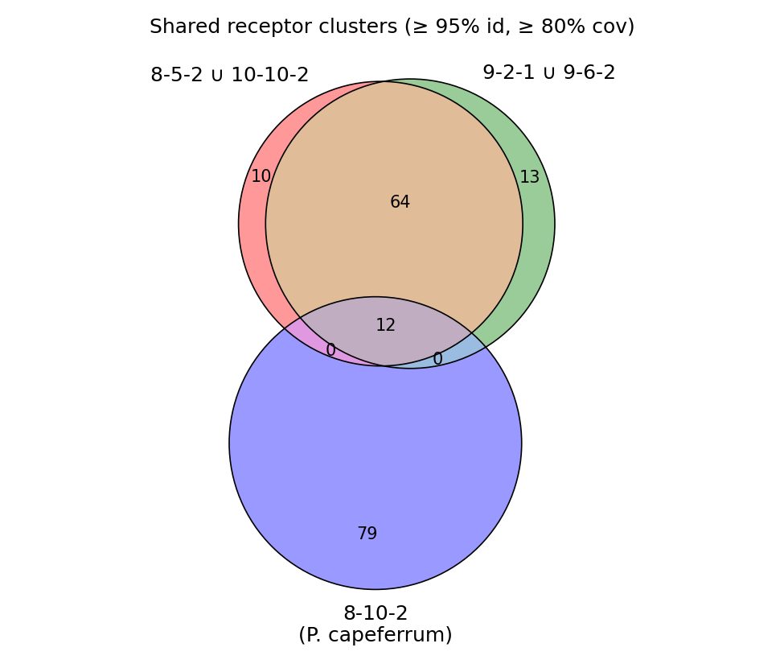

**Appendix A2.** Surface-receptor sharing across the five isolates (178 clusters). Twelve are shared by all five; 79 are unique to 8-10-2.

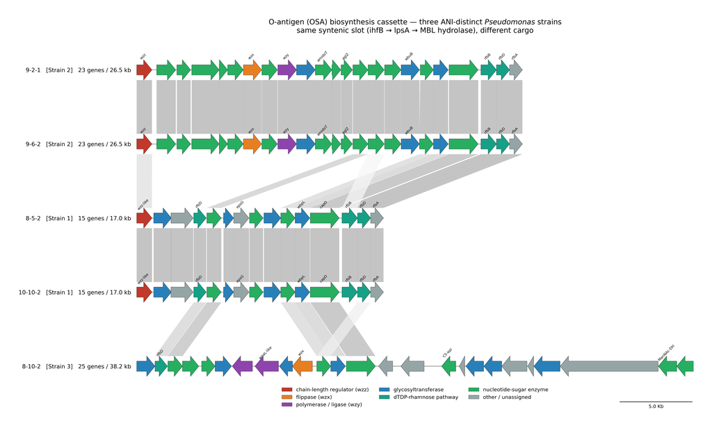

**Appendix A3.** O-antigen cassette comparison across the three strains (the §4 main figure). Five tracks, top to bottom: the two Strain 2 clones, the two Strain 1 clones, Strain 3. Arrows are genes, colour is functional role, grey ribbons are MMseqs homology links shaded by identity. **Two things to look at**: the clone pairs are joined by solid, full-width ribbons — that is the control; the cross-strain links are sparse and crossed — that is the result.

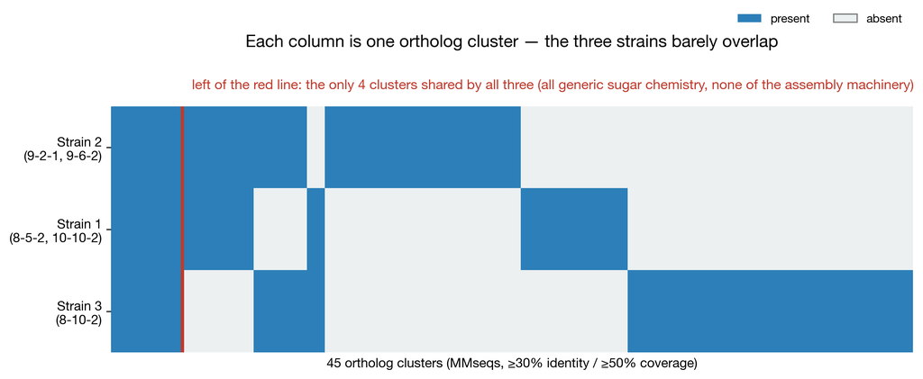

**Appendix A4.** Presence/absence of the 45 ortholog clusters. Only the 4 to the left of the red line are shared by all three strains; almost everything else is strain-specific.

**NoteHow A3 and A4 were made**

**Code** `code/0727_o_antigen_comparison/plot_loci.py`, `plot_summary_figs.py` **Tools** pyGenomeViz + MMseqs2 + matplotlib

**Judgements made:**

1. **The cassette is extracted by flanking anchors, not by hard-coded coordinates.** Its position differs in every genome; the only stable landmark is its neighbours, and `ihfB` is the literature-standard upstream flank of the *Pseudomonas* OSA cluster. The boundary rule walks from the MBL hydrolase to the end of the polysaccharide gene block, tolerating up to three consecutive non-polysaccharide genes (the 8-10-2 cassette contains a few hypotheticals).
2. **Orthology is called from sequence, not product strings.** Bakta gives unrelated glycosyltransferases identical labels. The case we actually hit: the chain-length regulators of Strains 1 and 2 carry different labels but are homologous — a name-based comparison would have missed it.
3. **Track order deliberately places the clone pairs adjacent**, so that “solid ribbons = control” and “sparse crossed links = result” can be read directly off the figure.
4. **`EpsG` and `Polysaccharide biosynthesis protein` are left grey and unassigned.** They are the usual labels for Wzy- and Wzx-family proteins, but Bakta assigns them no Pfam here (UniRef50 only), so they are **not coloured on a guess** — better that Strain 1 looks as if it is missing assembly machinery than that we assert something unevidenced. See §4.6, limit 3.
5. **The link shading floor is 20% identity**, matching the MMseqs search cutoff, so weak hits are not silently dropped.

**Pitfall worth recording**: MMseqs re-invokes itself internally and fails on paths containing spaces (this repository lives in `iGEM 26/`) — it must be run from the output directory with relative paths.

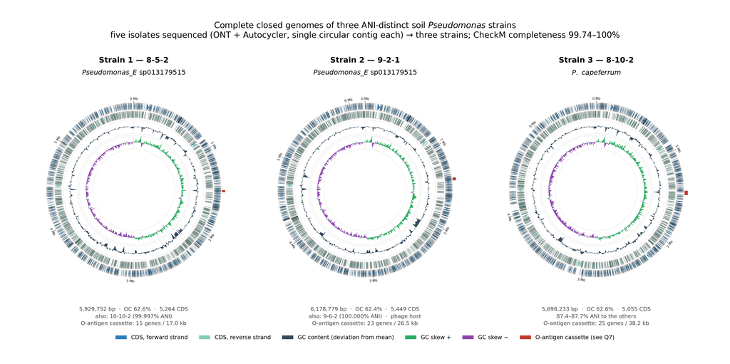

**Appendix A5 (item 3).** Complete closed genomes of the three strain representatives. Rings, outside in: **O-antigen cassette (red)**, forward-strand CDS, reverse-strand CDS, GC content deviation, GC skew. The GC skew flips polarity cleanly near the terminus in all three, which is what a correctly closed assembly should look like. **One map per strain, not per isolate**: 9-2-1 and 9-6-2 are 100.000% ANI, so drawing both would be drawing the same genome twice. The red cassette marker is what ties this figure to §4.

**NoteHow A5 was made**

**Code** `code/0729_prof_figures/plot_bacterial_genomes.py` **Tools** pyCirclize 1.10.1 reading the Bakta `.gbff`, assembled with matplotlib

**Judgements made:**

1. **One map per strain, not per isolate.** We sequenced five isolates but they collapse to three strains; 9-2-1 and 9-6-2 are 100.000% ANI, so drawing them separately would present the same genome twice. Drawing strain representatives is the honest choice.
2. **CDS counts are read from Bakta’s summary `.txt`, not by counting CDS features in the `.gbff`.** The two differ by **exactly 4** in every genome — Bakta writes its 4 sORFs as `CDS` features but reports them separately. A naive feature count would not match the MRA. This was checked, not assumed.
3. **GC content is plotted as deviation from the genome mean, not as absolute values.** These genomes all sit near 62% GC, so absolute values are a flat line; the deviation is what reveals horizontally acquired regions.
4. **The O-antigen cassette is marked in red on the outermost ring.** This is deliberate: it makes item 3 and item 7 one figure rather than two unrelated ones.
5. **GC skew is kept.** It is not decoration — the polarity flips cleanly near the terminus in all three, which is independent evidence that the assemblies are correctly closed, and useful for the MRA.

**Pitfalls worth recording**: pyCirclize’s `fill_between` requires explicit symmetric `vmin`/`vmax` for values straddling zero, and its `where=` argument no longer matches after the internal interpolation — clip the data into separate positive and negative series instead.

### 7.1.2 B. Phage genome and tail spike

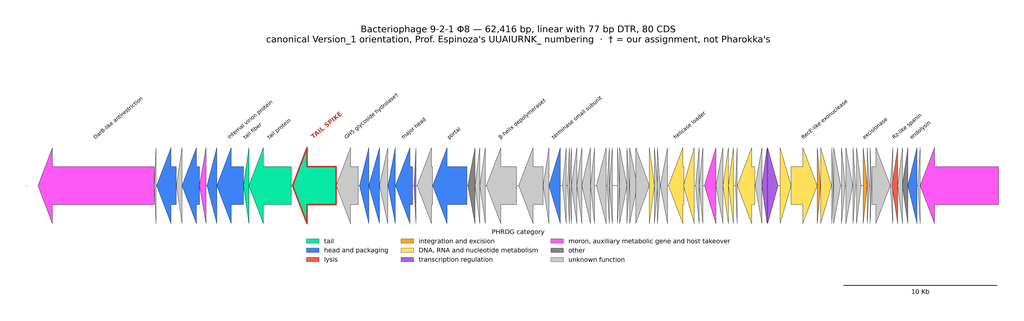

**Appendix B1 (item 4).** Genome map of 9-2-1 Φ8. All 80 CDS coloured by Pharokka PHROG category, with the **tail spike (CDS_0011) outlined in red**. Drawn on the canonical `Version_1` coordinates using the PI’s `UUAIURNK_` numbering — **this replaces the mirrored older version**. The two labels marked † (CDS_0012 = GH5; CDS_0024 = β-helix depolymerase) come from **our analysis, not from the Pharokka annotation**.

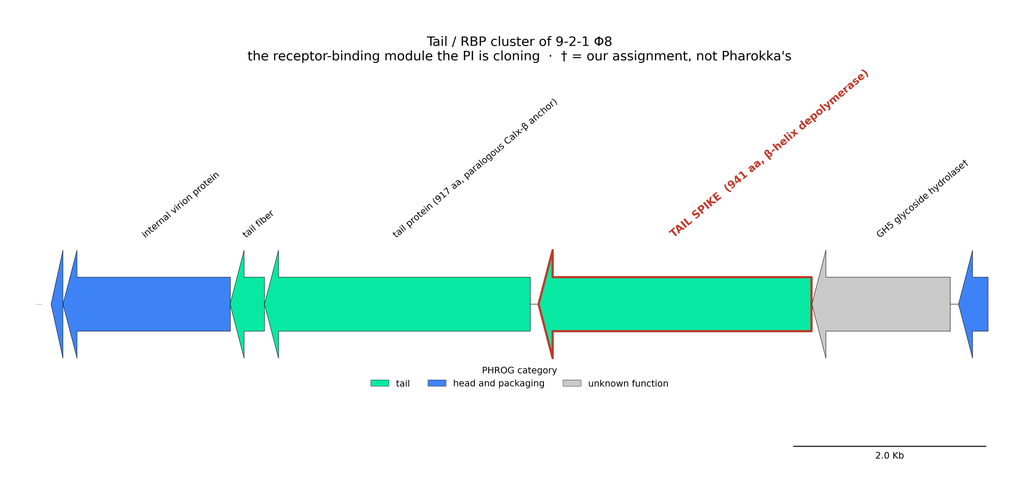

**Appendix B2 (item 4).** The tail / RBP cluster (CDS_0008–0012) enlarged — the module the PI is cloning.

**NoteHow B1 and B2 were made**

**Code** `code/0729_prof_figures/plot_phage_genome_map.py` **Tools** pyGenomeViz 1.7.0, reading the PI’s Pharokka TSV

**Judgements made:**

1. **Redrawn on the canonical `Version_1` coordinates and `UUAIURNK_` numbering.** This is the entire reason for redrawing: the old figure was on our reverse-complemented and rotated 62,338 bp frame, so its **module order was mirrored**. The same phage was annotated twice in opposite orientations — without switching frames, the genome is drawn backwards.
2. **Pharokka’s own PHROG category colours are reused** so the figure reads alongside standard Pharokka output and is familiar to reviewers. No new palette was invented.
3. **The tail spike is outlined rather than recoloured**, so it can be highlighted as the PI asked without breaking the category colour scheme.
4. **The † marks strictly separate our calls from Pharokka’s annotation.** Both CDS_0012 (GH5) and CDS_0024 (second depolymerase) are “hypothetical” to Pharokka; the assignments are ours. **We do not fold our own inferences into someone else’s annotation**, and the caption says so.
5. **The legend lists only the categories present in the drawn window.** The enlarged panel would otherwise advertise nine PHROG categories when only three appear in it.
6. **A zoom panel was added.** At whole-genome scale the 80 genes are too crowded to read the tail module the PI actually cares about.

**Pitfall worth recording**: `bbox_inches="tight"` expands the canvas upward to fit the rotated gene labels, which drops a figure-fraction-positioned `suptitle` in among them. Anchoring the title to the track axes is stable.

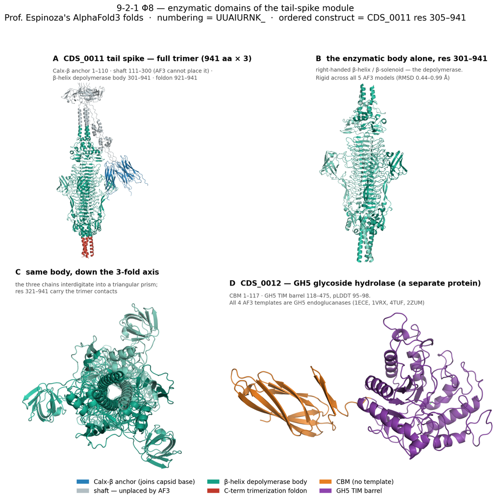

**Appendix B3 (item 6).** 3D models of the enzymatic domains of the tail-spike module, all from the PI’s own AF3 folds. **A** CDS_0011 trimer coloured by domain (Calx-β anchor, the unplaceable shaft, the β-helix body, the C-terminal foldon) — which also shows why the ordered construct begins at residue 305: the anchor and shaft land somewhere different in every model while the body is rigid. **B** the body alone (301–941), a β-solenoid. **C** the same body end-on down the three-fold axis. **D** CDS_0012, a CBM plus a GH5 TIM barrel. ⚠️ **D is a separate protein, not a domain of CDS_0011** — the wording of item 6 is ambiguous and the figure labels resolve it.

**NoteHow B3 was made**

**Code** `code/0729_prof_figures/render_enzymatic_domains.py` **Tools** PyMOL 3.1.0 headless (`from pymol import cmd`) for rendering, matplotlib for assembly

**Judgements made:**

1. **The ambiguity in the request is addressed directly rather than worked around.** Item 6 asks for the enzymatic domains *within* the tail spike, but the **template-confirmed** glycoside hydrolase (GH5) is **CDS_0012, a separate protein**, not a domain of CDS_0011. Panel D is included but its title says “a separate protein”. The enzyme genuinely inside the tail spike is the β-helix body in panels B and C.
2. **CDS_0010 is deliberately not drawn as an enzyme.** The PI describes it as a glycosidase, but the AF3 templates do not support that (one weak IspD hit; ~460 aa with no template). Including it would endorse an unverified claim. This is one of the three questions in §5.
3. **Domain boundaries come from measurement, not from eyeballing.** The 1–110 / 111–300 / 301–941 split follows `template_hits.tsv` from 0716 (all four templates cover only res 9–110) and `model_rmsd.tsv` (superposing the five models: body 0.44–0.99 Å, anchor 50–92 Å, shaft 41–52 Å).
4. **Panel A is itself the evidence for the construct decision.** It shows at a glance that the anchor and shaft are placed differently in every model while the body is rigid — which is why the ordered construct starts at **residue 305**. The title carries the construct range for that reason.
5. **Panel C (end-on, down the three-fold axis) was added** because the side view does not show that this is an interdigitated trimeric prism, and without that there is no way to explain why the C-terminal foldon must be kept.
6. **`model_0` of each AF3 job is used** (AF3’s own top-ranked model), not whichever looked best.

**Pitfalls worth recording**: PyMOL’s `cmd.color` does not accept hex colours — they must be registered with `cmd.set_color` first; after `orient()` the long axis lies along x, so the end-on view is `turn y 90`, not x; and PyMOL centres molecules in the canvas, so each render is auto-cropped to its content before tiling.

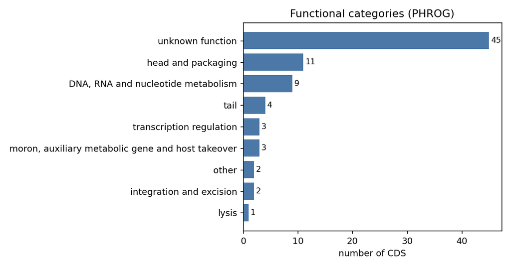

**Appendix B4.** Functional category distribution across the 80 CDS.

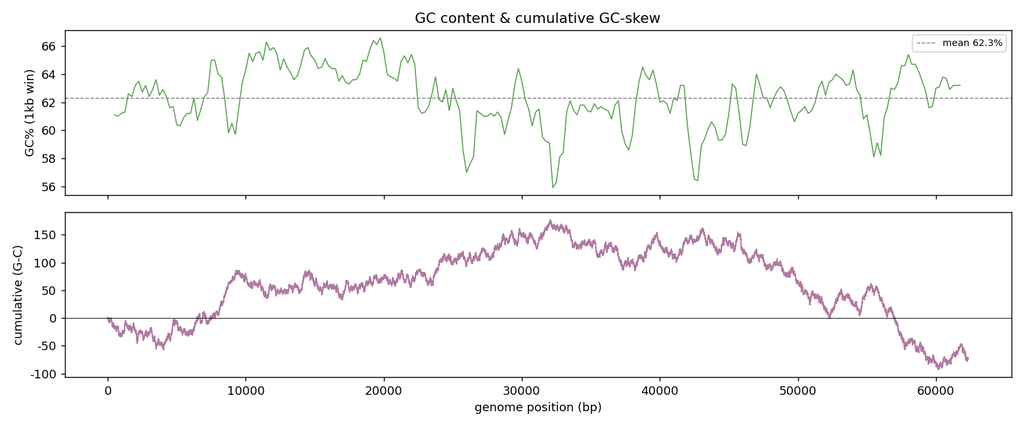

**Appendix B5.** GC content across the genome.

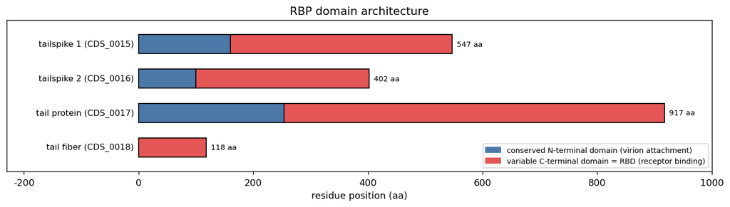

**Appendix B6.** Domain composition of the RBPs.

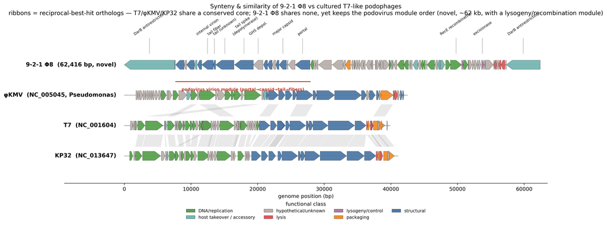

**Appendix B7 (C11–C13).** Synteny + similarity of 9-2-1 Φ8 against three cultured T7-like podophages — T7 (`NC_001604`), φKMV (`NC_005045`, *Pseudomonas*), KP32 (`NC_013647`). Four genome tracks, genes coloured by functional class; grey ribbons are reciprocal-best-hit orthologs between adjacent tracks. **Read it two ways.** (i) The three cultured T7-likes are tied together by a conserved core (RBH: T7↔︎KP32 = 40, T7↔︎φKMV = 6), but **9-2-1 Φ8 shares none** (RBH 0; one spurious 82-aa hit on the DarB gene) — positive controls pass (φKMV↔︎T7 = 6 at 25–33 % id; self-search 80/80), so the zero is real. (ii) Despite that, 9-2-1 Φ8 keeps the **canonical podovirus virion module** (bracketed: portal → capsid → tail → fibers), which is what confirms the CDS_20/08/09/13/14 assignments. It is also ~62 kb (vs ~40 kb) and carries a lysogeny/recombination module — a **novel, likely-temperate podovirus**, “T7-like” by organization only. Built in `code/0730_synteny_group_d/` (mmseqs RBH + PHROG synteny).

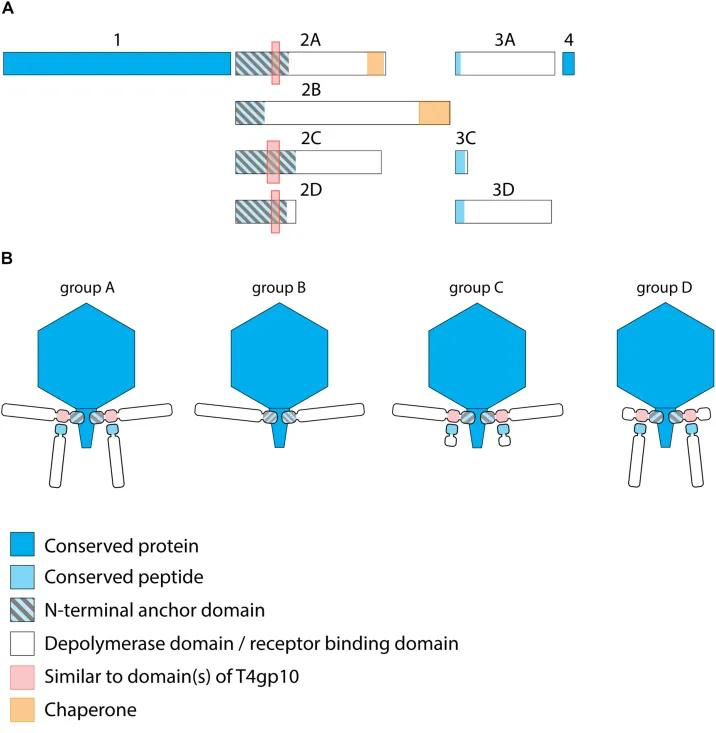

**Appendix B8 (C13).** The RBP-architecture groups of Latka & Briers 2019 — the cartoon the PI referenced. Group D (far right) = a first fiber that is a **T4gp10-like anchor with no enzymatic domain** (pink) + a second depolymerase RBP. 9-2-1 Φ8 has the *arrangement* — anchor-position CDS_0010 + depolymerase tail spike CDS_0011 — but **CDS_0010 carries no T4gp10 segment** (`code/0729_t4gp10_check/`), so it is **group-D-*like*, not group D**. Figure © Latka *et al.* 2019, *Front. Microbiol.* 10:2649 (CC BY).

### 7.1.3 C. Host range

[figure not shown]

**NoteHow C1 was made**

**Code** `code/0727_o_antigen_comparison/plot_summary_figs.py` **Tool** matplotlib

**Judgements made:**

1. **It is deliberately plain.** The only job of this figure is to **stop a prediction being read as data**. Grey means “no data in our hands yet” — the 8-5-2 / 10-10-2 / 8-10-2 cells were assayed by the PI on 2026-07-04, but that notebook has not reached us, so their readout is not shown; only Strain 2 has data behind it here.
2. **Only one cell is green because only one cell has data.** `data/assays/` contains OD600 for 9-2-1_p8 and 9-6-2_p8, both Strain 2. Nothing is interpolated or inferred.
3. **No colour gradient.** A gradient would imply graded likelihood, and we have no quantified likelihood — only “data in hand” and “not yet in hand”.

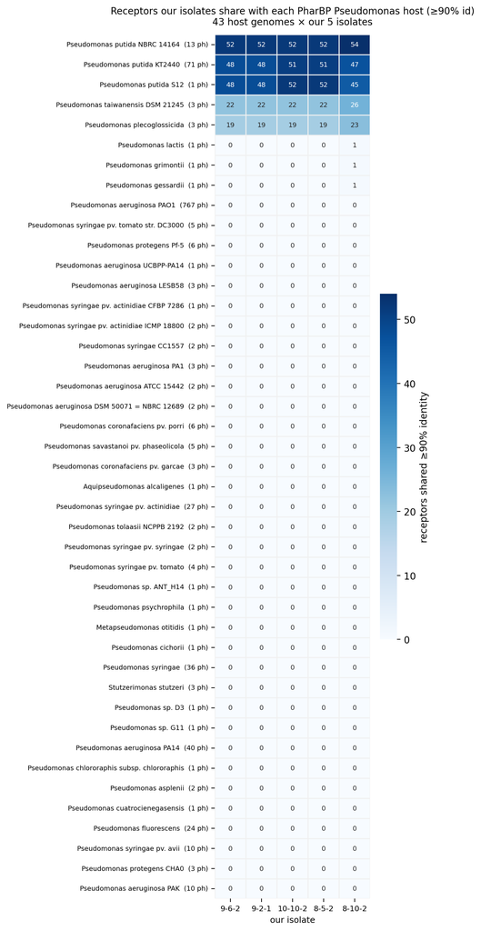

**Appendix C2.** Receptor sharing between our isolates and the PharBP host genomes (the surrogate-host analysis).

### 7.1.4 D. Wet lab

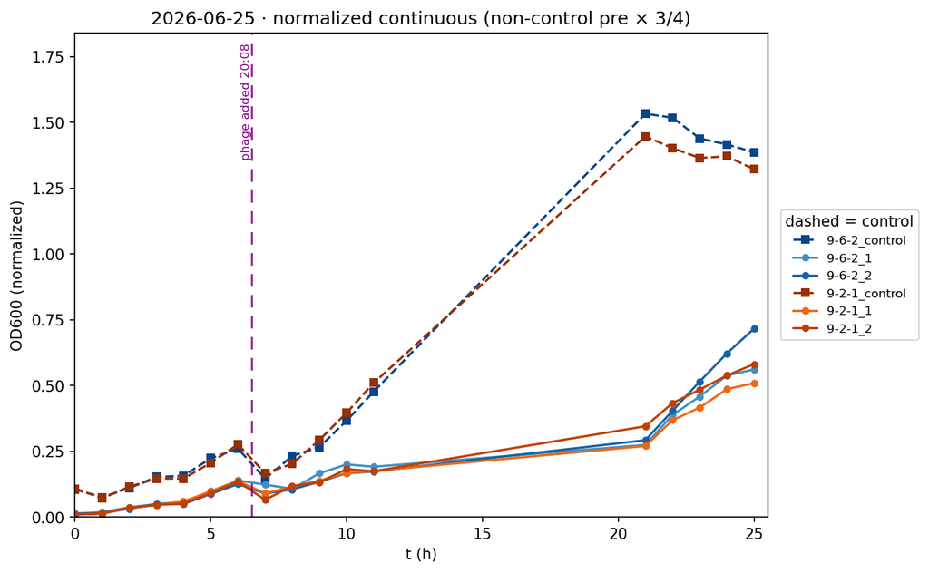

**Appendix D1.** OD600 curves from 0625 (normalized): 9-6-2 and 9-2-1, each × p8.

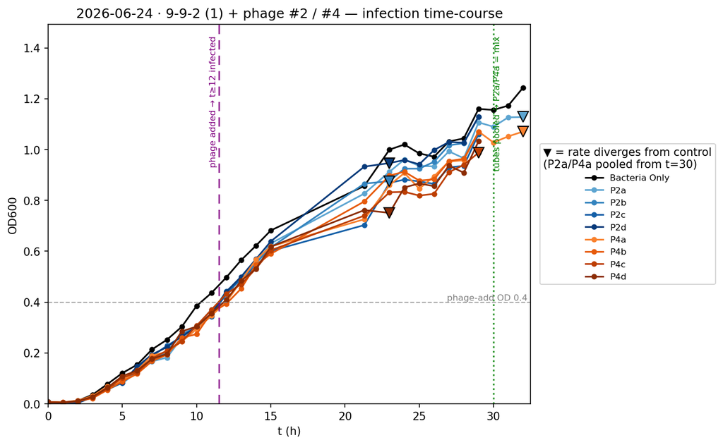

**Appendix D2.** OD600 curves from 0624: 9-9-2 × two plaque picks.

### 7.1.5 E. Negative results

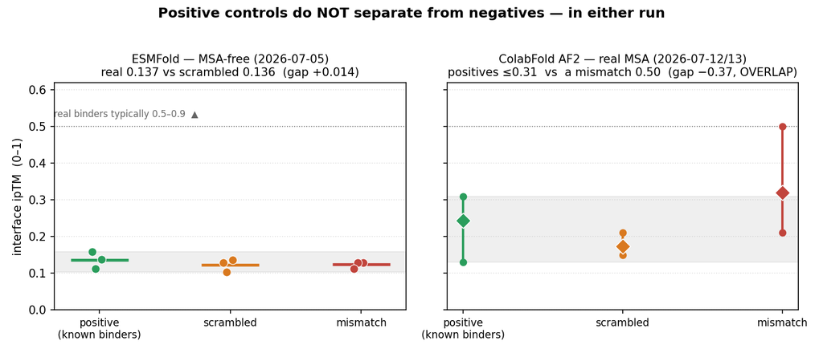

**Appendix E1.** The binding-screen controls: positives and mismatches overlap, so the score has no discriminating power. This figure is itself a publishable negative result.

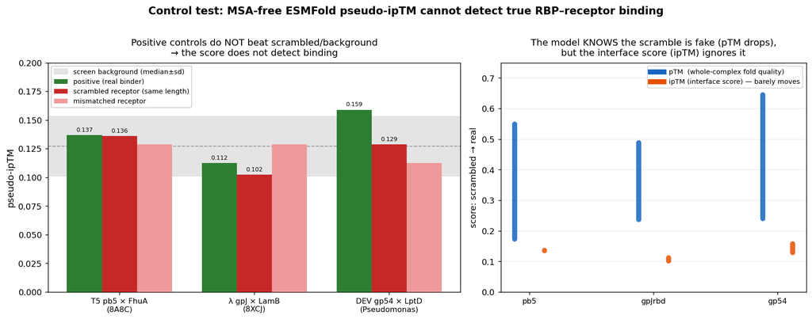

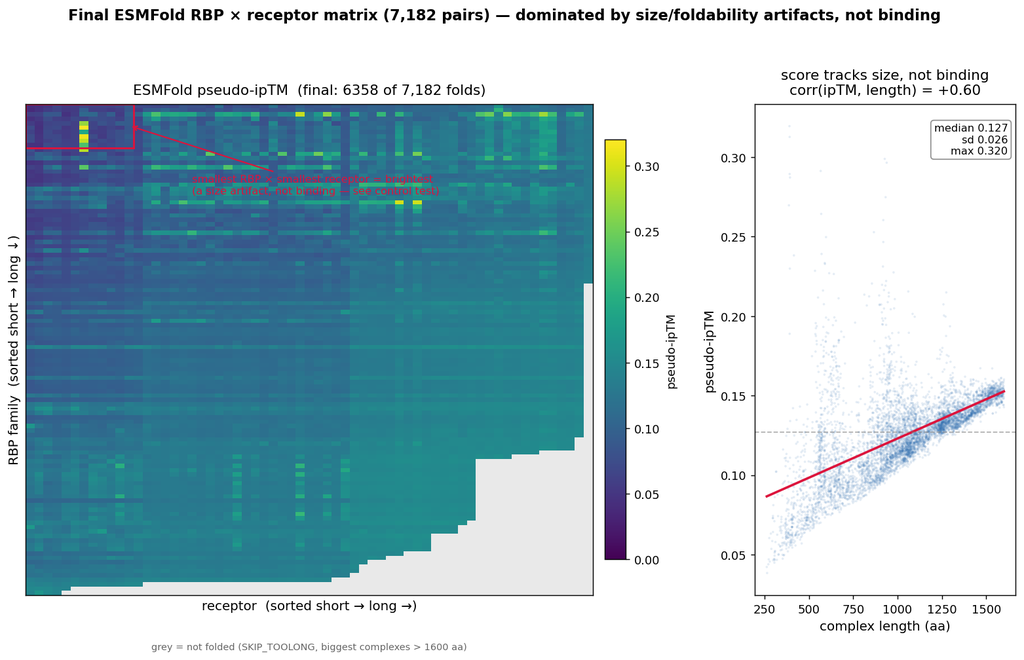

**Appendix E3.** The full ESMFold RBP × receptor matrix (7,182 pairs) behind E1/E2 — 6,358 folded. Pseudo-ipTM correlates with complex length (corr = +0.60): the score tracks size and foldability, **not binding**. This is the screen the controls invalidate; the retired approach is recorded here as a negative result.

**CautionThe “how it was made” notes cover only our own figures**

The method callouts above cover **A3, A4, A5, B1, B2, B3 and C1** — the figures produced by the 0727 and 0729 analyses, whose drawing decisions we can state accurately. **B7** (synteny) is fully documented in `code/0730_synteny_group_d/README.md`.

The remaining embedded figures (**A1, A2, B4–B6, B8, C2, D1, D2, E1–E3, F1, F2**) come from earlier analyses or external sources, and their methods are recorded in their own directories (see the index and source map below). **No decision notes were written for them, because doing so retrospectively would amount to inventing a rationale after the fact.** Read the original directory README before citing them in a Methods section.

### 7.1.6 F. Quantification / QC (illustrative)

DNA fluorometric quantification was run repeatedly (0605, 0608, 0622, 0629, 0710); one representative pair is shown — the rest are QC and live in their directories.

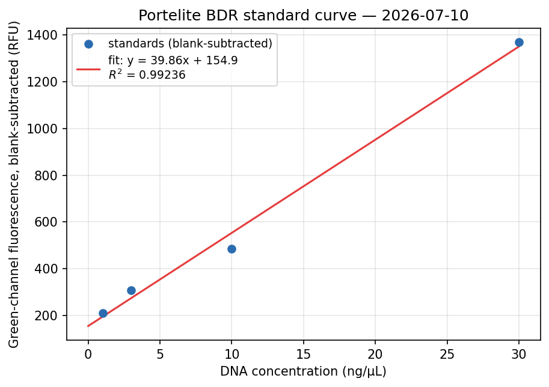

**Appendix F1.** Representative DNA standard curve (Portelite BDR green-channel fluorometry, 2026-07-10): blank-subtracted RFU vs DNA concentration, linear fit R² = 0.99.

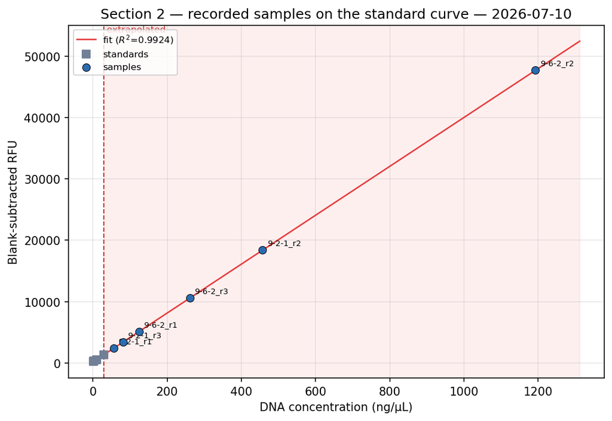

**Appendix F2.** Phage-DNA samples (9-2-1, 9-6-2 replicates) projected onto the same curve. ⚠️ Most samples fall in the **extrapolated** region (pink shading), above the highest 30 ng/µL standard — treat those concentrations as order-of-magnitude.

### 7.1.7 Figure index

| Directory | Count | Content |
| --- | --- | --- |
| `0605/0608/0622/0629/0710_quantification/` | 14 | DNA quantification standard curves and sample concentrations |
| `0617_receptor_similarity/` | 5 | receptor similarity heatmaps ×3, Venn ×2 |
| `0624/0625_od600_phage*/` | 11 | OD600 growth / lysis curves |
| `0626_genome_comparison/` | 3 | ANI heatmap, receptor Venn, receptor identity heatmap |
| `0703_phage_host_matrix/` | 6 | host overlap heatmaps, ipTM heatmap, control validation |
| `0708_phage_genome_analysis/` | 5 | phage genome map (obsolete), categories, GC, RBP domains |
| `0727_o_antigen_comparison/` | 3 | O-antigen cassette comparison, cluster matrix, host-range prediction |
| `0729_prof_figures/` | 4 | bacterial circular maps, phage genome map + tail module, enzymatic domains |
| `0730_synteny_group_d/` | 1 | 4-genome synteny + ortholog ribbons (App B7) |
| `documents/` + `2026-07-29_pi_conversation/images/` | 3 | binding control comparison; Latka group cartoon (B8); virion render |

## 7.2 Source map

| File / code | Date | What it shows |
| --- | --- | --- |
| `code/0729_prof_figures/` | 07-29 | **items 3, 4 and 6** — bacterial circular maps, phage genome map, enzymatic domain 3D |
| `code/0727_o_antigen_comparison/` | 07-27 | **all of §4** — cassette extraction, MMseqs orthology, three figures |
| `code/0716_espinoza_fiber_construct/` | 07-16 | CDS_0011 domain map, GH5 confirmation, construct options |
| `code/0713_espinoza_structural_mapping/` | 07-13 | the PI’s virion structural mapping + the **CDS numbering crosswalk** |
| `code/0712_phage_rbp_detect/` | 07-12 | β-helix depolymerase call, binding control gate |
| `code/0708_phage_assembly/` | 07-08 | phage assembly + Pharokka annotation |
| `code/0703_phage_host_matrix/` | 07-03 | host overlap matrix, ESMFold screen (retired) |
| `code/0626_genome_comparison.ipynb` | 06-26 | ANI matrix, receptor clustering, Table 1 |
| `code/0627_unique_strain_table.ipynb` | 06-27 | five isolates → three strains |
| `documents/2026-07-13_why_protein_protein_binding_fails.qmd` | 07-13 | the full account behind F1–F4 |
| `documents/2026-07-13_phage_rbp_depolymerase_findings.md` | 07-13 | the full account behind C1, C2, C5 |
| `documents/2026-07-12_rbp_variable_region_plan_review.md` | 07-12 | F5 — why item 5 is blocked |
| `documents/2026-06-27_MRA_Pseudomonas.docx` | 06-27 | the MRA draft (G1) |
| `documents/2026-07-27_twist_construct_order/` | 07-27 | the PI’s order to Twist + the three construct `.gb` files |

## 7.3 Reproducing the analyses

```bash
conda activate igem2026

# §4 — O-antigen cassette comparison (item 7)
python code/0727_o_antigen_comparison/extract_o_antigen_loci.py
python code/0727_o_antigen_comparison/compare_loci.py
python code/0727_o_antigen_comparison/plot_loci.py
python code/0727_o_antigen_comparison/plot_summary_figs.py

# Appendix figures — items 3, 4 and 6
python code/0729_prof_figures/plot_bacterial_genomes.py     # item 3
python code/0729_prof_figures/plot_phage_genome_map.py      # item 4
python code/0729_prof_figures/render_enzymatic_domains.py   # item 6

# C3/C4 — synteny + similarity vs T7-like podophages (2026-07-30)
WORK=/tmp/syn/work                                          # mmseqs needs a no-space path
python code/0730_synteny_group_d/extract_proteomes.py "$WORK"
WORK="$WORK" bash code/0730_synteny_group_d/run_mmseqs.sh
python code/0730_synteny_group_d/analyze_and_plot.py "$WORK"
```

*Log — 2026-07-28: built as the results synthesis in response to the PI’s 2026-07-27 seven-item email; inventoried 11 analysis dirs / 20 output dirs / 47 figures into 53 results across 7 groups with evidence grades. Seven-item status then: item 7 done (§4), item 1 = this document, items 3/4/6 material-ready, item 2 to converge, item 5 blocked. (Recorded in the zh original; carried here so both documents share one history.)*

*Log — 2026-07-29 (a): added a “how it was made” callout under each home-made appendix figure (tool, version, decisions, pitfalls) for direct reuse in a Methods section; added the tool-version table; noted the method callouts cover only the 0727/0729 home-made figures, and that no notes are written retrospectively for the earlier ones.*

*Log — 2026-07-29 (b): completed items 3, 4 and 6 (`code/0729_prof_figures/`), those three 🟡→🟢; appendices A5/B1/B2/B3 added; the old mirrored 0708 phage genome map (deprecated numbering) marked obsolete and replaced by B1.*

*Log — 2026-07-29 (c): created as the English counterpart of `2026-07-28_results_synthesis.qmd`, written for the PI, the manuscripts and the iGEM wiki rather than translated line by line. Same structure, same numbers, same figures; internal environment notes were dropped and the tool table kept in a form usable directly in a Methods section. The two documents are to be kept in sync — if a number changes in one, change it in the other.*

*Log — 2026-07-30: folded in the 2026-07-29 PI-conversation follow-up. CDS_0010 → “unknown protein” (C1); construct records reconciled with no C-terminal-tag detection downstream (C2); new synteny/similarity analysis (`code/0730_synteny_group_d/`) adds results **C11–C13** and **Appendix B7** — 9-2-1 Φ8 is a novel ~62 kb, likely-temperate podovirus, “T7-like” by virion-module synteny only, tail group-D-like without the T4gp10 anchor. Added a terse “bottom line” answer block at the top; embedded the Latka group cartoon (**B8**), the ESMFold RBP × receptor matrix (**E3**) and a representative DNA standard curve (**F1/F2**, one of the repeated 0605–0710 quantification runs). Also corrected the host-range wording (E4/E5, §4.5, App C1): the 8-5-2 / 10-10-2 / 8-10-2 strains were challenged in the PI’s 2026-07-04 assay — “awaiting his notebook”, not “never tested”. The `.qmd` is the source of truth; the `.html`/`.pdf` still need a re-render (pandoc 3.8 or quarto).*

*Note: no Quarto locally; the bundled `.html` was produced with pandoc 3.8 plus custom CSS emulating `theme: cosmo` (light, images inlined as data URIs). The `.qmd` is the source of truth; a later `quarto render` gives standard cosmo output.*